# Homework 4

Dorukhan Kılınç

1/29/2021

# 1.Introduction

In this homework my purpose is to forecast next 2 weeks of daily electricity consumption by using data between 01.01.2017-08.01.2021 and analyze my predictions by comparing them with the real values. Firstly, I will try to make the daily electricity consumption as stationary as possible because stationarity of the residuals is a crucial assumption for forecasting. To achieve stationarity, we should detrend and deaseasonalize the data and check for autocorrelation at lags. Then, I will use a suitable arima model to successfully model the residuals. After achieving a forecast for the residual values, I will inversely apply all the transformations I made to the new values and get forecasted daily electricity consumption values.

# 2.Data Manipulation and Achieving Stationarity

## a.Data Manipulation

From [EPIAS Transperency Platform](https://seffaflik.epias.com.tr/transparency/tuketim/gerceklesen-tuketim/gercek-zamanli-tuketim.xhtml), hourly electricity consumption values are taken. Since I will forecast daily values, I will take the mean of each days hourly consumption values. Summing them is also a choice, but we can always get the daily sum by simply multiplying daily mean with 24. Besides, studying with mean is easier to follow in the sense that values are smaller than that of summed case.

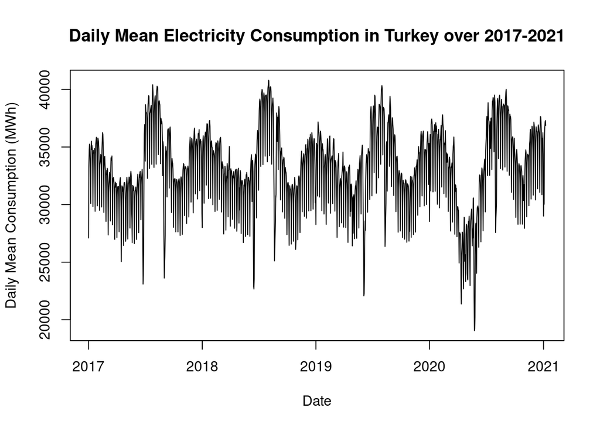

```r
library(data.table)
library(knitr)
library(zoo)
library(readxl)
library(corrplot)
library(ggplot2)
library(lubridate)
library(forecast)
library(urca)

dt = data.table(read_excel("ElectricityConsumption.xlsx", skip = 2, col_names= c("Date","Hour","Consumption")))
dt$Date = parse_date_time(dt$Date, "dmY")
dt[,Date:=as.Date(Date,format='%d-%m-%Y')]
dt_daily = copy(dt)
dt_daily[,dailyMeanConsumption:=mean(Consumption),by=Date]
dt_daily = dt_daily[!duplicated(Date)]
dt_daily[, Hour:=NULL]
dt_daily[, Consumption:=NULL]

plot(dt_daily, type = "l",
     ylab="Daily Mean Consumption (MWh)",
     main="Daily Mean Electricity Consumption in Turkey over 2017-2021")
```

Here is the plot of daily mean consumption.Firstly, although there exists a seasonality at each year, there is no obvious trend. We can easily eliminate seasonality by simply using a model with months as factors.

Another important thing to look is the autocorrelation function of our data. Before taking a look, it is reasonable to assume that there may be a large value at lag 7 since at each day of week, the consumption of electricity in workplaces will be similar to the consumption at the same day last week.

## b.Stationarity

### Check for Autocorrelation

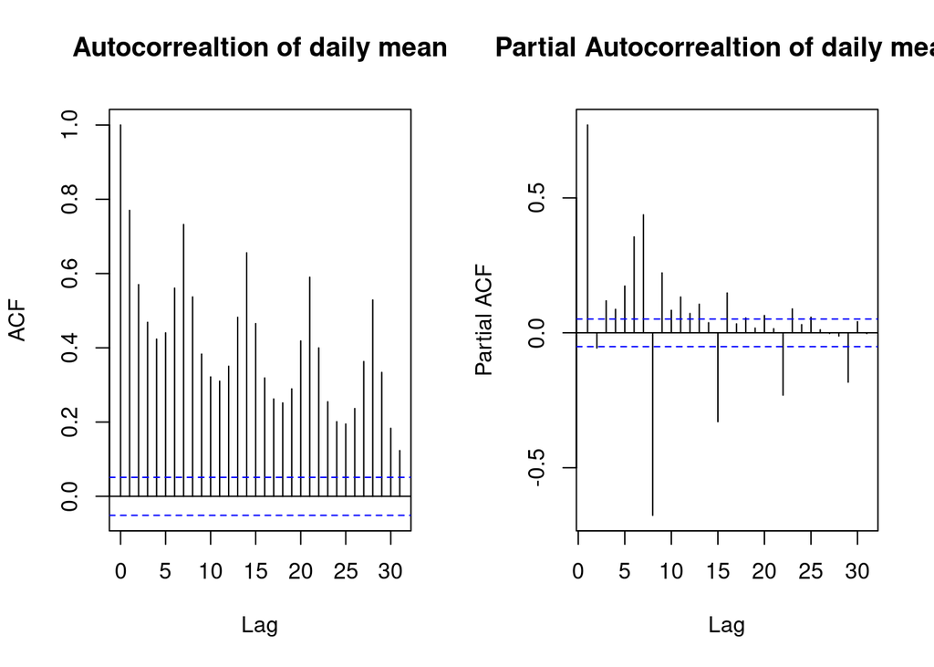

```r
par(mfrow = c(1,2))
acf(dt_daily$dailyMeanConsumption, main = "Autocorrealtion of daily mean")
pacf(dt_daily$dailyMeanConsumption, main = "Partial Autocorrealtion of daily mean")
```

It seems that there are autocorrelations at lags 1,7 and 8. Differencing at lag 1 can solve the autocorrelation at lag 1. Lag 7 may be because of the weekly seasonality I mentioned. Lag 8 might be because of a combined effect of lags 1 and 7.

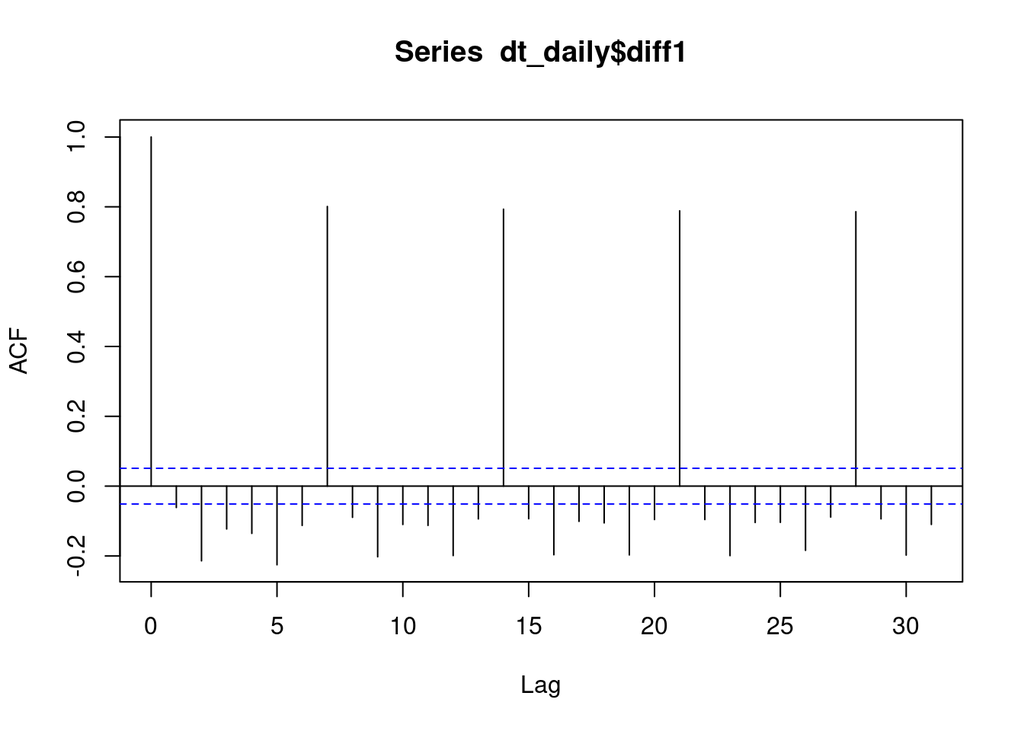

```r
dt_daily[, lag1:= shift(dailyMeanConsumption, 1)]
dt_daily[, diff1:=dailyMeanConsumption - lag1]
acf(dt_daily$diff1, na.action = na.pass)
```

```r
dt_daily$diff1%>%ur.kpss()%>%summary()
```

```
##
## #######################
## # KPSS Unit Root Test #
## #######################
##
## Test is of type: mu with 7 lags.
##
## Value of test-statistic is: 0.0101
##
## Critical value for a significance level of:
##                 10pct  5pct 2.5pct  1pct
## critical values 0.347 0.463  0.574 0.739
```

By differencing at lag 1, we can see that the large autocorrelation at lag 1 and 8 are disappeared. In the case at lag 7, high autocorrelation will be taken care of by adding weekdays as factors to the model.

### Linear Regression Models for Seasonal Effects

```r
#addintion of month and weekday columns to the data table
dt_daily[, month:= month(Date)]
dt_daily[, index:=1:.N]
dt_daily[, weekday:=index%%7]

#formation of the model
fit = lm(formula = diff1~ as.factor(weekday)+ as.factor(month) , data = dt_daily)
summary(fit)
```

```
##
## Call:
## lm(formula = diff1 ~ as.factor(weekday) + as.factor(month), data = dt_daily)
##
## Residuals:
##     Min      1Q  Median      3Q     Max
## -7088.3  -305.6     2.7   333.1  6899.6
##
## Coefficients:
##                     Estimate Std. Error t value Pr(>|t|)
## (Intercept)         -1541.51     114.42 -13.473   <2e-16 ***
## as.factor(weekday)1 -1675.86     102.78 -16.306   <2e-16 ***
## as.factor(weekday)2  5680.32     102.66  55.330   <2e-16 ***
## as.factor(weekday)3  2536.08     102.67  24.701   <2e-16 ***
## as.factor(weekday)4  1876.16     102.67  18.274   <2e-16 ***
## as.factor(weekday)5  1729.07     102.66  16.842   <2e-16 ***
## as.factor(weekday)6  1292.56     102.66  12.591   <2e-16 ***
## as.factor(month)2    -106.90     134.90  -0.792    0.428
## as.factor(month)3    -182.08     131.65  -1.383    0.167
## as.factor(month)4    -138.86     132.77  -1.046    0.296
## as.factor(month)5     -59.77     131.63  -0.454    0.650
## as.factor(month)6      53.86     132.77   0.406    0.685
## as.factor(month)7     -74.91     131.64  -0.569    0.569
## as.factor(month)8    -149.99     131.64  -1.139    0.255
## as.factor(month)9    -147.18     132.78  -1.108    0.268
## as.factor(month)10   -127.94     131.63  -0.972    0.331
## as.factor(month)11     13.86     132.77   0.104    0.917
## as.factor(month)12   -153.13     131.65  -1.163    0.245
## ---
## Signif. codes:  0 '***' 0.001 '**' 0.01 '*' 0.05 '.' 0.1 ' ' 1
##
## Residual standard error: 1051 on 1450 degrees of freedom
##   (1 observation deleted due to missingness)
## Multiple R-squared:  0.8026, Adjusted R-squared:  0.8003
## F-statistic: 346.8 on 17 and 1450 DF,  p-value: < 2.2e-16
```

First thing that we see is that actually months are not that relevant to our model. That is simply because of the differencing we did. Subtracting two consecutive days neutralized the effect of months. To see how our models performance changes, lets create another model with only weekdays as factors.

```r
#formation of the model
fit2 = lm(formula = diff1~ as.factor(weekday), data = dt_daily)
summary(fit2)
```

```
##
## Call:
## lm(formula = diff1 ~ as.factor(weekday), data = dt_daily)
##
## Residuals:
##     Min      1Q  Median      3Q     Max
## -7149.3  -312.6    -2.8   337.5  7042.3
##
## Coefficients:
##                     Estimate Std. Error t value Pr(>|t|)
## (Intercept)         -1631.56      72.57  -22.48   <2e-16 ***
## as.factor(weekday)1 -1676.65     102.63  -16.34   <2e-16 ***
## as.factor(weekday)2  5681.30     102.51   55.42   <2e-16 ***
## as.factor(weekday)3  2537.12     102.51   24.75   <2e-16 ***
## as.factor(weekday)4  1877.35     102.51   18.31   <2e-16 ***
## as.factor(weekday)5  1730.34     102.51   16.88   <2e-16 ***
## as.factor(weekday)6  1294.50     102.51   12.63   <2e-16 ***
## ---
## Signif. codes:  0 '***' 0.001 '**' 0.01 '*' 0.05 '.' 0.1 ' ' 1
##
## Residual standard error: 1049 on 1461 degrees of freedom
##   (1 observation deleted due to missingness)
## Multiple R-squared:  0.8016, Adjusted R-squared:  0.8008
## F-statistic: 983.9 on 6 and 1461 DF,  p-value: < 2.2e-16
```

By omitting months from our model, we can say we achieved a better model by looking at the slight improvements of residual standard error and adjusted r-squared values. Therefore, I will adopt this model and continue.

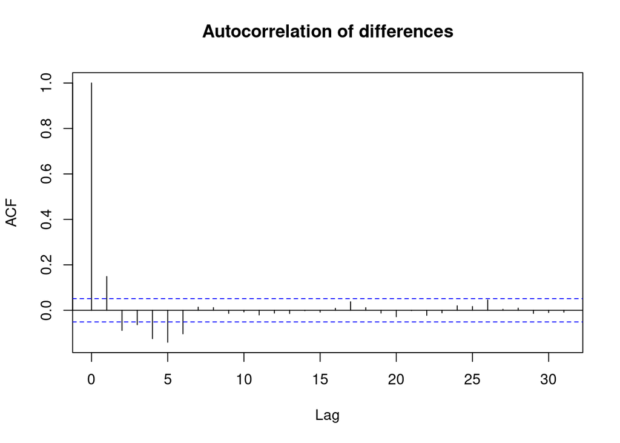

```r
dt_daily[, SeasonalityAdjustedDiff:= c(NA,fit2$residuals)]

acf(dt_daily$SeasonalityAdjustedDiff, na.action = na.pass, main="Autocorrelation of differences")
```

```r
dt_daily$SeasonalityAdjustedDiff%>%ur.kpss()%>%summary()
```

```
##
## #######################
## # KPSS Unit Root Test #
## #######################
##
## Test is of type: mu with 7 lags.
##
## Value of test-statistic is: 0.0088
##
## Critical value for a significance level of:
##                 10pct  5pct 2.5pct  1pct
## critical values 0.347 0.463  0.574 0.739
```

As we can see, after differencing, there is not any high autocorrelation value left. The p-value for kpss test is small enough that the null hypothesis that the data is stationary can not be rejected at any of the critical significance levels. To improve our model, outliers such as holidays can be handled. Doing outlier analysis may result in a better acf.

## c.Outliers

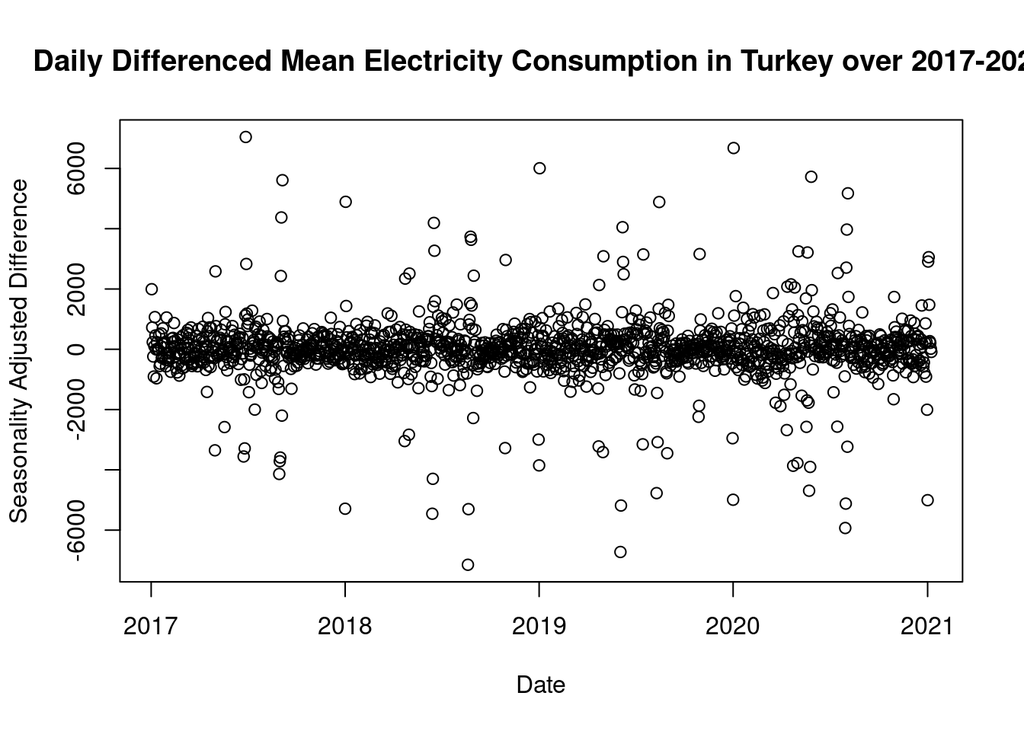

```r
plot(y=dt_daily$SeasonalityAdjustedDiff, x=dt_daily$Date, xlab="Date",
     ylab = "Seasonality Adjusted Difference", main = "Daily Differenced Mean Electricity Consumption in Turkey over 2017-2021")
```

By looking at the plot we can say that there are some outliers whose existence may be damaging our model. There are several ways to deal with outliers. One way of dealing with them is manually marking and then adjusting them using values from one week before and after. However, this method is time consuming in the sense that we need to manually all of the holidays. Therefore, I am going to mark points with absolute seasonality adjusted difference bigger than 2000 as outlier points because data seems to be located mostly between -2000 and 2000.

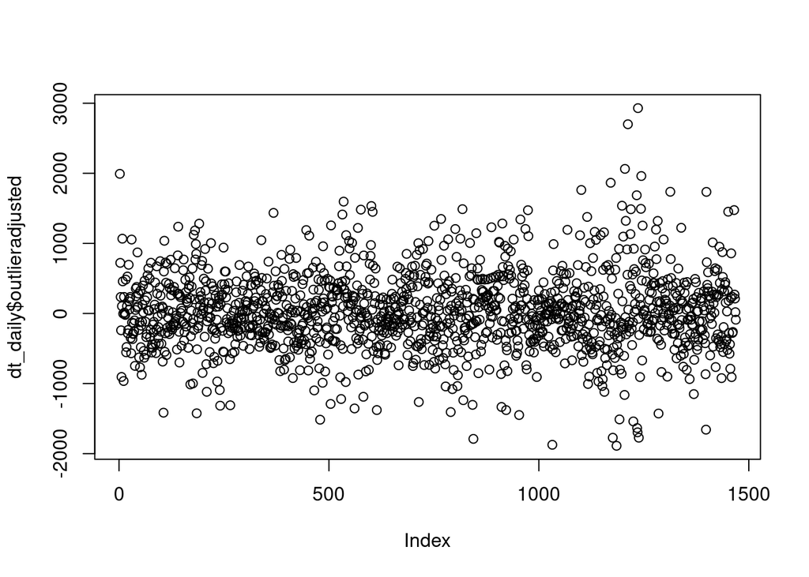

```r
#outlier
dt_daily[,special:=0]
dt_daily[abs(SeasonalityAdjustedDiff) > 2000, special := 1]
dt_daily[, outlieradjusted := SeasonalityAdjustedDiff]

dt_daily[, difflag7 := shift(SeasonalityAdjustedDiff, 7)]
dt_daily[, difffor7 := shift(SeasonalityAdjustedDiff, -7)]

dt_daily[special == 1, outlieradjusted := (difflag7 + difffor7)/2]

plot(dt_daily$outlieradjusted)
```

After adjusting outliers, our plot seems to have more uniform variance. Now we can proceed into modeling with arima.

# 3.Arima Model and Predictions

## a.Arima Model

```r
model = auto.arima(dt_daily$outlieradjusted, seasonal = F)
summary(model)
```

```
## Series: dt_daily$outlieradjusted
## ARIMA(1,0,2) with non-zero mean
##
## Coefficients:
##          ar1      ma1      ma2     mean
##       0.3542  -0.2522  -0.1253  28.8279
## s.e.  0.2103   0.2091   0.0294  13.5988
##
## sigma^2 estimated as 292458:  log likelihood=-11303.78
## AIC=22617.57   AICc=22617.61   BIC=22644.03
##
## Training set error measures:
##                     ME     RMSE      MAE       MPE     MAPE      MASE
## Training set 0.2305959 540.0555 399.9926 -3.133788 1014.555 0.7367278
##                      ACF1
## Training set -0.001009181
```

Using auto.arima, most suitable model is the one with one autoregressive and two moving average terms. Now we can move on to predictions and see how well our model performs.

## b.Predictions

In this section, we will predict the differenced and seasonality adjusted residuals using the arima model we constructed. Then we will seasonalize our data by adding predictions from our daily factored model. And, finally we will transform this differenced predictions to predictions of daily mean consumptions by using the consumption of 8th January to predict the 9th and so on.

```r
#forecast the differenced and seasonality subtracted daily mean consumption
forecasted = forecast(model, h=14)
predictions = rep(0, length.out = 14)

weekday = c(0:6,0:6)

#predict the effect of days for next two week
seasonalComp = predict(fit2, newdata = data.frame(weekday))

#Add seasonality to the forecasted differences
predictions = forecasted$mean
predictions = predictions + seasonalComp

#yt_1 is the mean consumption of the last day in our data
yt_1 = dt_daily[.N, dailyMeanConsumption]

#Using yt_1 transform first prediction of difference to the prediction of the mean consumption.
predictions[1] = predictions[1] + yt_1

#Transform all differences in the prediction vector into consumption values.
for(j in 2:14){
  predictions[j] = predictions[j] + predictions[j-1]
}

predictions = as.data.table(predictions)

Date = as.Date('2021-01-09')
for(k in 2:14){
  Date[k] = Date[k-1]+1
}
Date = as.data.table(Date)
predictions = cbind(Date, predictions)
predictions
```

```
##           Date        x
##  1: 2021-01-09 35246.33
##  2: 2021-01-10 31967.28
##  3: 2021-01-11 36045.96
##  4: 2021-01-12 36980.38
##  5: 2021-01-13 37255.01
##  6: 2021-01-14 37382.62
##  7: 2021-01-15 37074.39
##  8: 2021-01-16 35471.66
##  9: 2021-01-17 32192.28
## 10: 2021-01-18 36270.84
## 11: 2021-01-19 37205.22
## 12: 2021-01-20 37479.84
## 13: 2021-01-21 37607.44
## 14: 2021-01-22 37299.21
```

Here above our predictions for next two weeks starting from 9th January 2021. Inverse transformation steps of the prediction is also commented in the code. Now that we have our predictions, we can evaluate our predictions and, naturally, our model.

# 4.Model Performance and Conclusion

Because this homework is submitted on 29th January, I have the actual consumption data for forecasted days. Now I will put them into another vector and apply some statistical tests to see how well our model predicted.

```r
v = c(34781.56,31841.90,36431.46,36897.99,37409.87,38056.05,38170.38,
      35667.35,32557.96,38447.89,39723.73,39960.92,39791.07,38902.97)

predictions[, real:=v]

statsind = function(actual, forecasted){
   n=length(actual)
   error = actual-forecasted
   bias = error/actual
   wmape = abs(error)/actual
   l = data.frame(actual, forecasted, error, bias, wmape)
   return(l)
}

stats <- function(actual, forecasted){
  n=length(actual)
  error = actual-forecasted
  mean=mean(actual)
  sd=sd(actual)
  bias = sum(error)/sum(actual)
  mape = sum(abs(error/actual))/n
  mad = sum(abs(error))/n
  wmape = mad/mean
  l = data.frame(n,mean,sd,bias,mape,mad,wmape)
  return(l)
}

statsind(v, predictions$x[1:14])
```

```
##      actual forecasted      error         bias       wmape
## 1  34781.56   35246.33 -464.77287 -0.013362623 0.013362623
## 2  31841.90   31967.28 -125.38249 -0.003937657 0.003937657
## 3  36431.46   36045.96  385.49783  0.010581454 0.010581454
## 4  36897.99   36980.38  -82.39482 -0.002233044 0.002233044
## 5  37409.87   37255.01  154.85838  0.004139506 0.004139506
## 6  38056.05   37382.62  673.42576  0.017695630 0.017695630
## 7  38170.38   37074.39 1095.98665  0.028713014 0.028713014
## 8  35667.35   35471.66  195.69060  0.005486547 0.005486547
## 9  32557.96   32192.28  365.68015  0.011231667 0.011231667
## 10 38447.89   36270.84 2177.04705  0.056623317 0.056623317
## 11 39723.73   37205.22 2518.50569  0.063400534 0.063400534
## 12 39960.92   37479.84 2481.08352  0.062087748 0.062087748
## 13 39791.07   37607.44 2183.62608  0.054877290 0.054877290
## 14 38902.97   37299.21 1603.75880  0.041224585 0.041224585
```

```r
stats(v, predictions$x[1:14])
```

```
##    n     mean       sd       bias       mape      mad      wmape
## 1 14 37045.79 2567.339 0.02537903 0.02682819 1036.265 0.02797254
```

Here above are firstly our models performance for each day and then an overall performance analysis. Looking at weighted mean absolute percentage error (wmape), we can say that we were able to guess this two weeks’ mean consumption with a n error rate of 2.8%. However, these statistics are not that much useful just by themselves. We simply need a base case or statistics for other models to decide whether or not to adopt this model. Therefore, Let’s look at another case. For a base scenario, because we observed a high autocorrelation at lag 7, I will us last weeks’ mean consumption values.

```r
base = rep(tail(dt_daily$dailyMeanConsumption,7),2)
stats(v, base)
```

```
##    n     mean       sd       bias       mape     mad      wmape
## 1 14 37045.79 2567.339 0.05935869 0.05998296 2198.99 0.05935869
```